# Ex 6. Analysis of longitudinal data

## RATS data analysis

The data for this analysis consists of weight observations over 64 days of rats separatet for three groups.

```r
library(dplyr)
library(tidyr)
library(ggplot2)
```

Firstly, we will implement the analyses of Chapter 8 of MABS using the RATS data.

```r
# read the RATS data
# load the data (saved in long form)
rats_long <- read.table("C:/R scripts/IODS-project/data/rats_long.txt", header = TRUE)

#wide format data
rats <- read.table("https://raw.githubusercontent.com/KimmoVehkalahti/MABS/master/Examples/data/rats.txt", sep = "\t", header = T)

str(rats_long)
```

```
## 'data.frame':    176 obs. of  5 variables:
##  $ ID         : int  1 2 3 4 5 6 7 8 9 10 ...
##  $ Group      : int  1 1 1 1 1 1 1 1 2 2 ...
##  $ WD         : chr  "WD1" "WD1" "WD1" "WD1" ...
##  $ measurement: int  240 225 245 260 255 260 275 245 410 405 ...
##  $ Time       : int  1 1 1 1 1 1 1 1 1 1 ...
```

```r
str(rats)
```

```
## 'data.frame':    16 obs. of  13 variables:
##  $ ID   : int  1 2 3 4 5 6 7 8 9 10 ...
##  $ Group: int  1 1 1 1 1 1 1 1 2 2 ...
##  $ WD1  : int  240 225 245 260 255 260 275 245 410 405 ...
##  $ WD8  : int  250 230 250 255 260 265 275 255 415 420 ...
##  $ WD15 : int  255 230 250 255 255 270 260 260 425 430 ...
##  $ WD22 : int  260 232 255 265 270 275 270 268 428 440 ...
##  $ WD29 : int  262 240 262 265 270 275 273 270 438 448 ...
##  $ WD36 : int  258 240 265 268 273 277 274 265 443 460 ...
##  $ WD43 : int  266 243 267 270 274 278 276 265 442 458 ...
##  $ WD44 : int  266 244 267 272 273 278 271 267 446 464 ...
##  $ WD50 : int  265 238 264 274 276 284 282 273 456 475 ...
##  $ WD57 : int  272 247 268 273 278 279 281 274 468 484 ...
##  $ WD64 : int  278 245 269 275 280 281 284 278 478 496 ...
```

```r
# making factors out of ID and Group variables
rats_long$ID <- factor(rats_long$ID)
rats_long$Group <- factor(rats_long$Group)

str(rats_long) #done!
```

```
## 'data.frame':    176 obs. of  5 variables:
##  $ ID         : Factor w/ 16 levels "1","2","3","4",..: 1 2 3 4 5 6 7 8 9 10 ...
##  $ Group      : Factor w/ 3 levels "1","2","3": 1 1 1 1 1 1 1 1 2 2 ...
##  $ WD         : chr  "WD1" "WD1" "WD1" "WD1" ...
##  $ measurement: int  240 225 245 260 255 260 275 245 410 405 ...
##  $ Time       : int  1 1 1 1 1 1 1 1 1 1 ...
```

```r
# summary of the variables
summary(rats_long)
```

```
##        ID      Group       WD             measurement         Time
##  1      : 11   1:88   Length:176         Min.   :225.0   Min.   : 1.00
##  2      : 11   2:44   Class :character   1st Qu.:267.0   1st Qu.:15.00
##  3      : 11   3:44   Mode  :character   Median :344.5   Median :36.00
##  4      : 11                             Mean   :384.5   Mean   :33.55
##  5      : 11                             3rd Qu.:511.2   3rd Qu.:50.00
##  6      : 11                             Max.   :628.0   Max.   :64.00
##  (Other):110
```

To begin we shall plot the rats values for all rats, differentiating between the groups into which the rats have been randomized.

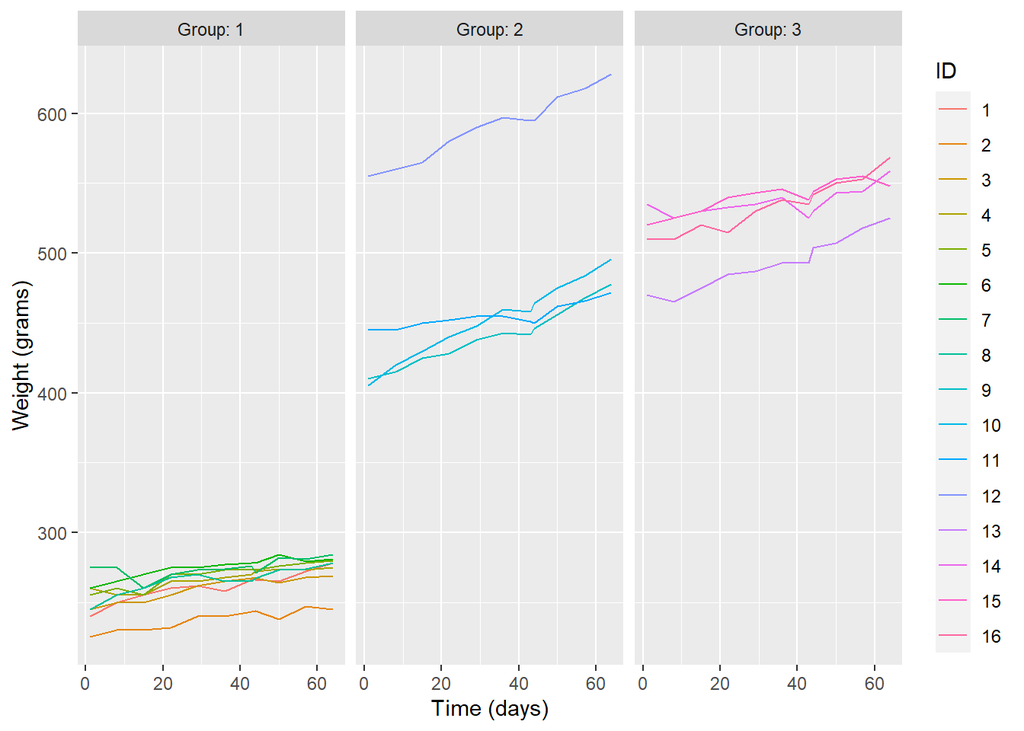

```r
ggplot(rats_long, aes(x = Time, y = measurement, col=ID)) +
  geom_line() +
  facet_grid(. ~ Group, labeller = label_both) +
  scale_x_continuous(name = "Time (days)")+
  scale_y_continuous(name = "Weight (grams)")
```

We want to observe how rats that had big wheit from the beggining end to have higher weight throughout the study. This phenomenon is generally referred to as tracking.

The tracking phenomenon can be seen more clearly in a plot of the standardized values of each observation.

```r
# Standardize the scores
rats_long <- rats_long %>%
  group_by(Time) %>%
  mutate( stdrats = (measurement - mean(measurement))/sd(measurement) ) %>%
  ungroup()
glimpse(rats_long)
```

```
## Rows: 176
## Columns: 6
## $ ID          <fct> 1, 2, 3, 4, 5, 6, 7, 8, 9, 10, 11, 12, 13, 14, 15, 16, 1, ~
## $ Group       <fct> 1, 1, 1, 1, 1, 1, 1, 1, 2, 2, 2, 2, 3, 3, 3, 3, 1, 1, 1, 1~
## $ WD          <chr> "WD1", "WD1", "WD1", "WD1", "WD1", "WD1", "WD1", "WD1", "W~
## $ measurement <int> 240, 225, 245, 260, 255, 260, 275, 245, 410, 405, 445, 555~
## $ Time        <int> 1, 1, 1, 1, 1, 1, 1, 1, 1, 1, 1, 1, 1, 1, 1, 1, 8, 8, 8, 8~
## $ stdrats     <dbl> -1.0011429, -1.1203857, -0.9613953, -0.8421525, -0.8819001~
```

Making a plot using standartizied values.

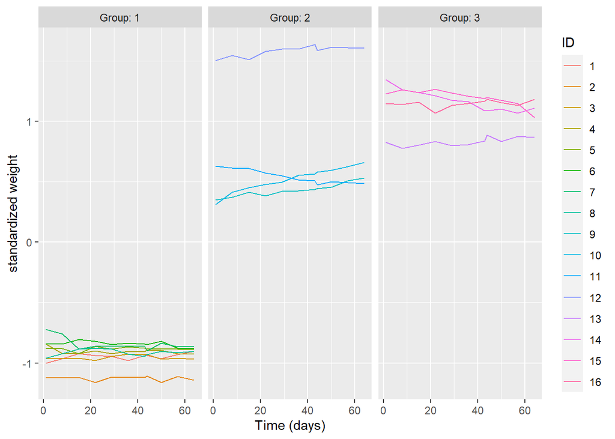

```r
ggplot(rats_long, aes(x = Time, y = stdrats, col=ID)) +
  geom_line() +
  facet_grid(. ~ Group, labeller = label_both) +
  scale_x_continuous(name = "Time (days)")+
  scale_y_continuous(name = "standardized weight")
```

Now we can see that trend of the observations is not clear anymore while before we could clearely see the trend for growth.

Next, we will produce graphs showing average (mean) profiles for each treatment group along with some indication of the variation of the observations at each time point, in this case the standard error of mean.

```r
# number of days, baseline (day 1) included
n <- 20
# summary data with mean and standard error of measurement by Group and time
summ_rats <- rats_long %>%
  group_by(Group, Time) %>%
  summarise( mean = mean(measurement), se = sd(measurement)/sqrt(n) ) %>%
  ungroup()
glimpse(summ_rats)
```

```
## Rows: 33
## Columns: 4
## $ Group <fct> 1, 1, 1, 1, 1, 1, 1, 1, 1, 1, 1, 2, 2, 2, 2, 2, 2, 2, 2, 2, 2, 2~
## $ Time  <int> 1, 8, 15, 22, 29, 36, 43, 44, 50, 57, 64, 1, 8, 15, 22, 29, 36, ~
## $ mean  <dbl> 250.625, 255.000, 254.375, 261.875, 264.625, 265.000, 267.375, 2~
## $ se    <dbl> 3.403648, 2.927700, 2.566091, 3.041234, 2.472528, 2.634930, 2.44~
```

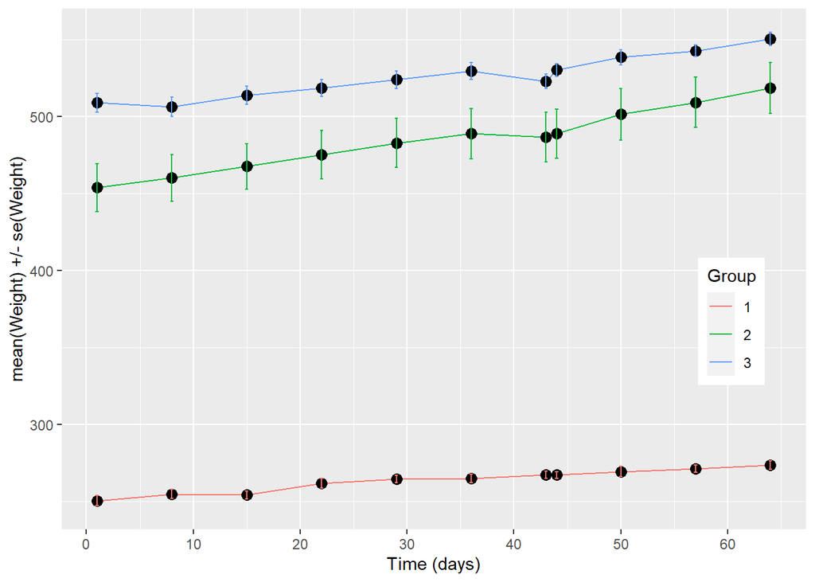

```r
# plotting the mean profiles with errorbars
ggplot(summ_rats, aes(x = Time, y = mean)) +
  geom_line(aes(col=Group)) +
  geom_point(size=3) +
  scale_shape_manual(values = c(1,2,3)) +
  geom_errorbar(aes(ymin=mean-se, ymax=mean+se, col = Group), width=0.3) +
  theme(legend.position = c(0.9,0.4)) +
  scale_x_continuous(name = "Time (days)", breaks = seq(0, 60, 10)) +
  scale_y_continuous(name = "mean(Weight) +/- se(Weight)")
```

```r
# I changed the plot that was given on DataCamp out of curiosity and I ended up thinking that color representation of the groups is prettier :)
```

Next, we look into differencies between groups and producing boxplots of the mean values of each group.

```r
# creating a summary data by Group and ID with mean as the summary variable (excluding the baseline)
gr_summ_rats <- rats_long %>%
  filter(Time > 1) %>%
  group_by(Group, ID) %>%
  summarise( mean=mean(measurement) ) %>%
  ungroup()
str(gr_summ_rats)
```

```
## tibble [16 x 3] (S3: tbl_df/tbl/data.frame)
##  $ Group: Factor w/ 3 levels "1","2","3": 1 1 1 1 1 1 1 1 2 2 ...
##  $ ID   : Factor w/ 16 levels "1","2","3","4",..: 1 2 3 4 5 6 7 8 9 10 ...
##  $ mean : num [1:16] 263 239 262 267 271 ...
```

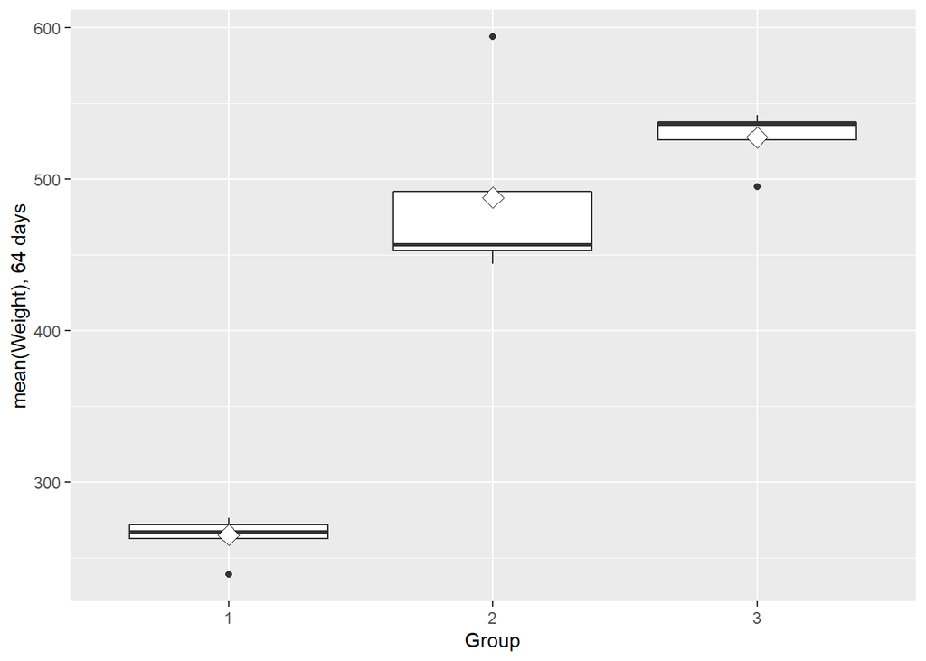

```r
# draw a boxplot of the mean versus Group
ggplot(gr_summ_rats, aes(x = Group, y = mean)) +
  geom_boxplot() +
  stat_summary(fun.y = "mean", geom = "point", shape=23, size=4, fill = "white") +
  scale_y_continuous(name = "mean(Weight), 64 days")
```

As expected, we can see that one there is an otliner in the froup 2 since the variation is big and the distribution is notably skewed. The outliner must be higher than average.

We will drop the outliner and vizualize the boxplot again.

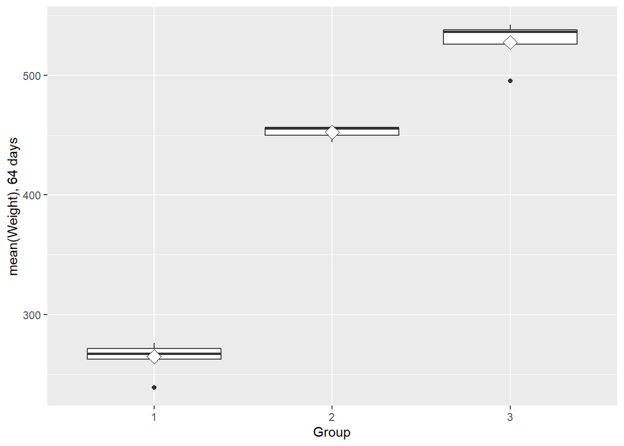

```r
# create a new data by filtering the outlier and adjust the ggplot code the draw the plot again with the new data
gr_summ_rats.nooutl <- gr_summ_rats %>% filter(mean < 570)

ggplot(gr_summ_rats.nooutl, aes(x = Group, y = mean)) +
  geom_boxplot() +
  stat_summary(fun.y = "mean", geom = "point", shape=23, size=4, fill = "white") +
  scale_y_continuous(name = "mean(Weight), 64 days")
```

```r
# add the baseline from the original data as a new variable to the summary data
gr_summ_rats1 <- gr_summ_rats %>%
  mutate(baseline = rats$WD1)

# fit the linear model with the mean as the response
model <- lm(mean ~ baseline + Group, data = gr_summ_rats1)
model
```

```
##
## Call:
## lm(formula = mean ~ baseline + Group, data = gr_summ_rats1)
##
## Coefficients:
## (Intercept)     baseline       Group2       Group3
##     33.1637       0.9251      34.8575      23.6753
```

```r
# compute the analysis of variance table for the fitted model with anova()
anova(model)
```

```
## Analysis of Variance Table
##
## Response: mean
##           Df Sum Sq Mean Sq   F value   Pr(>F)
## baseline   1 253625  253625 1859.8201 1.57e-14 ***
## Group      2    879     439    3.2219  0.07586 .
## Residuals 12   1636     136
## ---
## Signif. codes:  0 '***' 0.001 '**' 0.01 '*' 0.05 '.' 0.1 ' ' 1
```

Analysis showed that there is no evidence of a group difference.

## BPRS data analysis

The BPRS data, in which 40 male subjects were randomly assigned to one of two treatment groups and each subject was rated on the brief psychiatric rating scale (BPRS) measured before treatment began (week 0) and then at weekly intervals for eight weeks. The BPRS assesses the level of 18 symptom constructs such as hostility, suspiciousness, hallucinations and grandiosity; each of these is rated from one (not present) to seven (extremely severe). The scale is used to evaluate patients suspected of having schizophrenia.

```r
# load the data (saved in long form)
bprs_long <- read.table("C:/R scripts/IODS-project/data/bprs_long.txt", header = TRUE)

#checking the data structure
str(bprs_long)
```

```
## 'data.frame':    360 obs. of  5 variables:
##  $ treatment: int  1 1 1 1 1 1 1 1 1 1 ...
##  $ subject  : int  1 2 3 4 5 6 7 8 9 10 ...
##  $ weeks    : chr  "week0" "week0" "week0" "week0" ...
##  $ bprs     : int  42 58 54 55 72 48 71 30 41 57 ...
##  $ week     : int  0 0 0 0 0 0 0 0 0 0 ...
```

```r
# making factors out of treatment and subject variables
bprs_long$treatment <- factor(bprs_long$treatment)
bprs_long$subject <- factor(bprs_long$subject)

# summaries of the variables
summary(bprs_long)
```

```
##  treatment    subject       weeks                bprs            week
##  1:180     1      : 18   Length:360         Min.   :18.00   Min.   :0
##  2:180     2      : 18   Class :character   1st Qu.:27.00   1st Qu.:2
##            3      : 18   Mode  :character   Median :35.00   Median :4
##            4      : 18                      Mean   :37.66   Mean   :4
##            5      : 18                      3rd Qu.:43.00   3rd Qu.:6
##            6      : 18                      Max.   :95.00   Max.   :8
##            (Other):252
```

```r
str(bprs_long) #data has the right form for the continuation of the analysis
```

```
## 'data.frame':    360 obs. of  5 variables:
##  $ treatment: Factor w/ 2 levels "1","2": 1 1 1 1 1 1 1 1 1 1 ...
##  $ subject  : Factor w/ 20 levels "1","2","3","4",..: 1 2 3 4 5 6 7 8 9 10 ...
##  $ weeks    : chr  "week0" "week0" "week0" "week0" ...
##  $ bprs     : int  42 58 54 55 72 48 71 30 41 57 ...
##  $ week     : int  0 0 0 0 0 0 0 0 0 0 ...
```

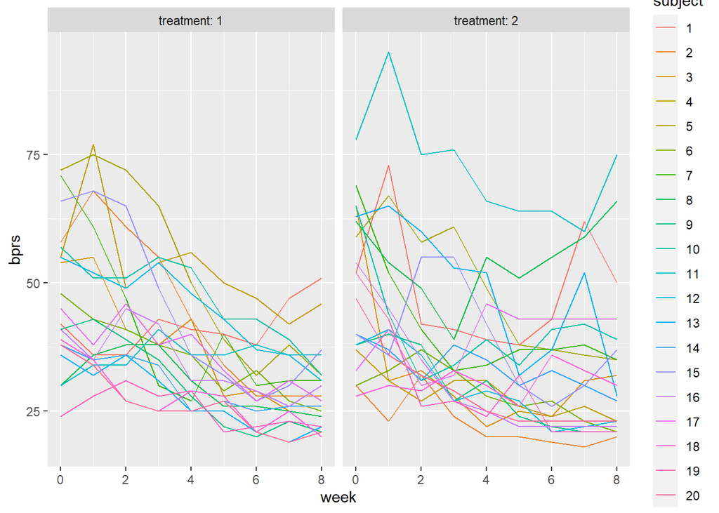

```r
# graph showing all the data
ggplot(bprs_long, aes(x = week, y = bprs, col = subject)) +
  geom_line() +
  facet_grid(. ~ treatment, labeller = label_both) +
  scale_y_continuous(limits = c(min(bprs_long$bprs), max(bprs_long$bprs)))
```

We can see that the differences bettween the observations are big and there is not clear average trend. Roughly, we can recognize some decrese pattern here. One probable pattern is that bprs goes down untill week 5 ot 6 and then go up.

Next, e will plot the data, identifying the observations in each tretment group but ignoring the longitudinal nature of the data.

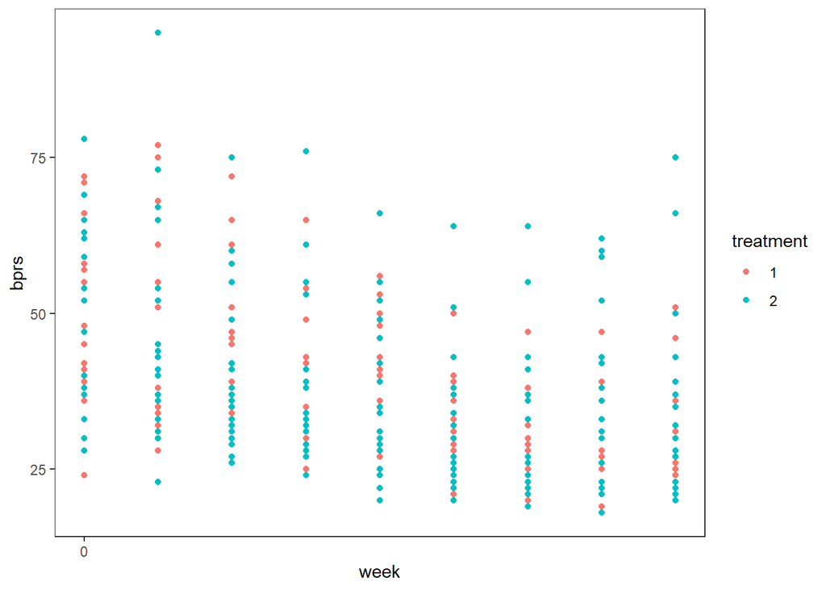

```r
ggplot(bprs_long, aes(x = week, y = bprs, group = subject))+ geom_point(aes(col = treatment))+  scale_x_continuous(name = "week", breaks = seq(0, 60, 10)) + scale_y_continuous(name = "bprs") + theme_bw()+ theme(panel.grid.major = element_blank(), panel.grid.minor = element_blank())
```

```r
# create a regression model2
model2 <- lm(bprs ~ week + treatment, data = bprs_long)
model2
```

```
##
## Call:
## lm(formula = bprs ~ week + treatment, data = bprs_long)
##
## Coefficients:
## (Intercept)         week   treatment2
##     46.4539      -2.2704       0.5722
```

```r
# print out a summary of the model
summary(model2)
```

```
##
## Call:
## lm(formula = bprs ~ week + treatment, data = bprs_long)
##
## Residuals:
##     Min      1Q  Median      3Q     Max
## -22.454  -8.965  -3.196   7.002  50.244
##
## Coefficients:
##             Estimate Std. Error t value Pr(>|t|)
## (Intercept)  46.4539     1.3670  33.982   <2e-16 ***
## week         -2.2704     0.2524  -8.995   <2e-16 ***
## treatment2    0.5722     1.3034   0.439    0.661
## ---
## Signif. codes:  0 '***' 0.001 '**' 0.01 '*' 0.05 '.' 0.1 ' ' 1
##
## Residual standard error: 12.37 on 357 degrees of freedom
## Multiple R-squared:  0.1851, Adjusted R-squared:  0.1806
## F-statistic: 40.55 on 2 and 357 DF,  p-value: < 2.2e-16
```

Here, treatment 2 doesn`t give a significnat difference (p=0.661).

```r
library(lme4)
# Create a random intercept model
int_model <- lmer(bprs ~ week + treatment + (1 | subject), data = bprs_long, REML = FALSE)

# Print the summary of the model
summary(int_model)
```

```
## Linear mixed model fit by maximum likelihood  ['lmerMod']
## Formula: bprs ~ week + treatment + (1 | subject)
##    Data: bprs_long
##
##      AIC      BIC   logLik deviance df.resid
##   2748.7   2768.1  -1369.4   2738.7      355
##
## Scaled residuals:
##     Min      1Q  Median      3Q     Max
## -3.0481 -0.6749 -0.1361  0.4813  3.4855
##
## Random effects:
##  Groups   Name        Variance Std.Dev.
##  subject  (Intercept)  47.41    6.885
##  Residual             104.21   10.208
## Number of obs: 360, groups:  subject, 20
##
## Fixed effects:
##             Estimate Std. Error t value
## (Intercept)  46.4539     1.9090  24.334
## week         -2.2704     0.2084 -10.896
## treatment2    0.5722     1.0761   0.532
##
## Correlation of Fixed Effects:
##            (Intr) week
## week       -0.437
## treatment2 -0.282  0.000
```

```r
# create a random intercept and random slope model
int_slope_model <- lmer(bprs ~ week + treatment + (week | subject), data = bprs_long, REML = FALSE)
int_slope_model
```

```
## Linear mixed model fit by maximum likelihood  ['lmerMod']
## Formula: bprs ~ week + treatment + (week | subject)
##    Data: bprs_long
##       AIC       BIC    logLik  deviance  df.resid
##  2745.440  2772.643 -1365.720  2731.440       353
## Random effects:
##  Groups   Name        Std.Dev. Corr
##  subject  (Intercept) 8.0512
##           week        0.9802   -0.51
##  Residual             9.8707
## Number of obs: 360, groups:  subject, 20
## Fixed Effects:
## (Intercept)         week   treatment2
##     46.4539      -2.2704       0.5722
```

```r
# print a summary of the model
summary(int_slope_model)
```

```
## Linear mixed model fit by maximum likelihood  ['lmerMod']
## Formula: bprs ~ week + treatment + (week | subject)
##    Data: bprs_long
##
##      AIC      BIC   logLik deviance df.resid
##   2745.4   2772.6  -1365.7   2731.4      353
##
## Scaled residuals:
##     Min      1Q  Median      3Q     Max
## -2.8919 -0.6194 -0.0691  0.5531  3.7976
##
## Random effects:
##  Groups   Name        Variance Std.Dev. Corr
##  subject  (Intercept) 64.8222  8.0512
##           week         0.9609  0.9802   -0.51
##  Residual             97.4305  9.8707
## Number of obs: 360, groups:  subject, 20
##
## Fixed effects:
##             Estimate Std. Error t value
## (Intercept)  46.4539     2.1052  22.066
## week         -2.2704     0.2977  -7.626
## treatment2    0.5722     1.0405   0.550
##
## Correlation of Fixed Effects:
##            (Intr) week
## week       -0.582
## treatment2 -0.247  0.000
```

```r
# perform an ANOVA test on the two models
anova(int_model, int_slope_model)
```

```
## Data: bprs_long
## Models:
## int_model: bprs ~ week + treatment + (1 | subject)
## int_slope_model: bprs ~ week + treatment + (week | subject)
##                 npar    AIC    BIC  logLik deviance  Chisq Df Pr(>Chisq)
## int_model          5 2748.7 2768.1 -1369.4   2738.7
## int_slope_model    7 2745.4 2772.6 -1365.7   2731.4 7.2721  2    0.02636 *
## ---
## Signif. codes:  0 '***' 0.001 '**' 0.01 '*' 0.05 '.' 0.1 ' ' 1
```

We can see that the random intercept and random slope model is a better fit for the data (p = 0.02) even though the significnace is quite close to the cut off.

Finally, we can fit a random intercept and slope model that allows for a group × time interaction.

```r
# create a random intercept and random slope model with the interaction
final_model <- lmer(bprs ~ week * treatment + (week | treatment), data = bprs_long, REML = FALSE)
final_model
```

```
## Linear mixed model fit by maximum likelihood  ['lmerMod']
## Formula: bprs ~ week * treatment + (week | treatment)
##    Data: bprs_long
##       AIC       BIC    logLik  deviance  df.resid
##  2843.303  2874.392 -1413.652  2827.303       352
## Random effects:
##  Groups    Name        Std.Dev.  Corr
##  treatment (Intercept) 5.071e-04
##            week        7.948e-05 -1.00
##  Residual              1.228e+01
## Number of obs: 360, groups:  treatment, 2
## Fixed Effects:
##     (Intercept)             week       treatment2  week:treatment2
##         47.8856          -2.6283          -2.2911           0.7158
## optimizer (nloptwrap) convergence code: 0 (OK) ; 0 optimizer warnings; 1 lme4 warnings
```

```r
# print a summary of the model
summary(final_model)
```

```
## Linear mixed model fit by maximum likelihood  ['lmerMod']
## Formula: bprs ~ week * treatment + (week | treatment)
##    Data: bprs_long
##
##      AIC      BIC   logLik deviance df.resid
##   2843.3   2874.4  -1413.7   2827.3      352
##
## Scaled residuals:
##     Min      1Q  Median      3Q     Max
## -1.9453 -0.7547 -0.2281  0.5304  4.1794
##
## Random effects:
##  Groups    Name        Variance  Std.Dev.  Corr
##  treatment (Intercept) 2.571e-07 5.071e-04
##            week        6.318e-09 7.948e-05 -1.00
##  Residual              1.508e+02 1.228e+01
## Number of obs: 360, groups:  treatment, 2
##
## Fixed effects:
##                 Estimate Std. Error t value
## (Intercept)      47.8856     1.6876  28.376
## week             -2.6283     0.3545  -7.415
## treatment2       -2.2911     2.3866  -0.960
## week:treatment2   0.7158     0.5013   1.428
##
## Correlation of Fixed Effects:
##             (Intr) week   trtmn2
## week        -0.840
## treatment2  -0.707  0.594
## wek:trtmnt2  0.594 -0.707 -0.840
## optimizer (nloptwrap) convergence code: 0 (OK)
## boundary (singular) fit: see ?isSingular
```

```r
# perform an ANOVA test on the two models - with interaction and without
anova(final_model, int_slope_model)
```

```
## Data: bprs_long
## Models:
## int_slope_model: bprs ~ week + treatment + (week | subject)
## final_model: bprs ~ week * treatment + (week | treatment)
##                 npar    AIC    BIC  logLik deviance Chisq Df Pr(>Chisq)
## int_slope_model    7 2745.4 2772.6 -1365.7   2731.4
## final_model        8 2843.3 2874.4 -1413.7   2827.3     0  1          1
```

Here we get 1 degree of freedom and p = 1, thereofre, the last doesn`t provide additional information for the analysis. So, we will use the previous model for the analysis.

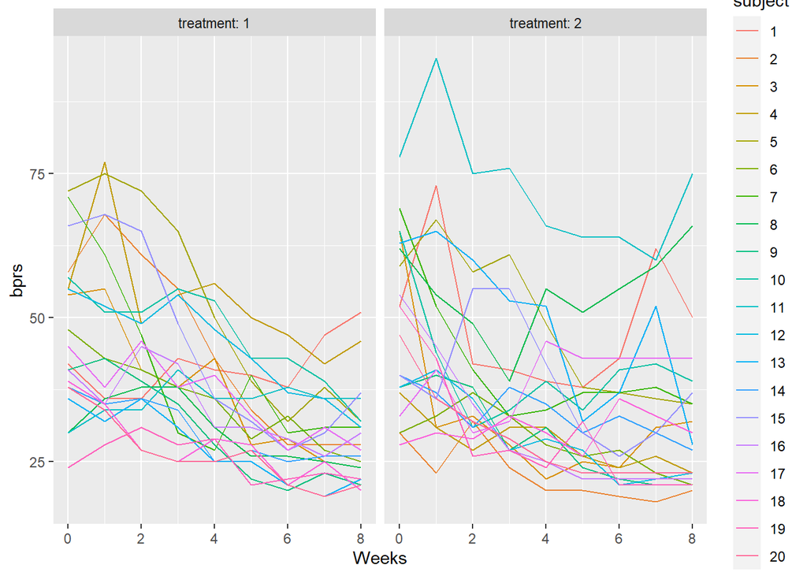

```r
# draw the plot of RATSL with the observed Weight values
ggplot(bprs_long, aes(x = week, y = bprs, col = subject)) +
  geom_line() +
  scale_x_continuous(name = "Weeks") +
  scale_y_continuous(name = "bprs") +
  scale_linetype_manual(values = rep(1:10, times=4)) +
  facet_grid(. ~ treatment, labeller = label_both)
```

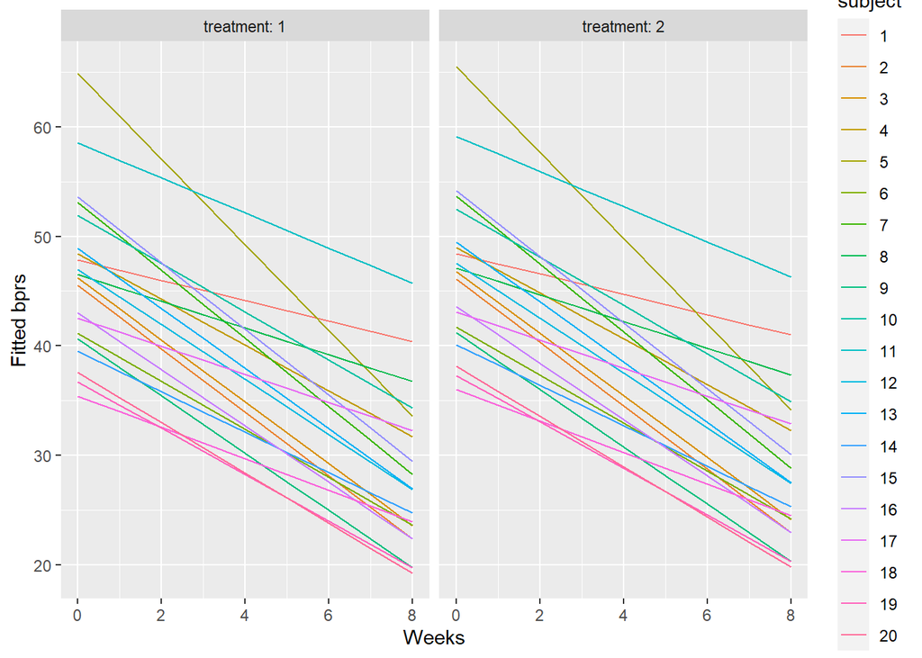

```r
# create a vector of the fitted values from the wanted model
Fitted <- fitted(int_slope_model)

# create a new column fitted to RATSL
bprs_long <- bprs_long %>% mutate(fitted = Fitted)

# draw the plot of RATSL with the Fitted values of weight
ggplot(bprs_long, aes(x = week, y = Fitted, col = subject)) +
  geom_line() +
  scale_x_continuous(name = "Weeks") +
  scale_y_continuous(name = "Fitted bprs")  +
  scale_linetype_manual(values = rep(1:10, times=4)) +
  facet_grid(. ~ treatment, labeller = label_both)
```

Looking at the model, it can be concluded that there is no tratment that worked better since the results for the both groups are having a similar pattern.  
——————–  
That`s all. Thank you for the course! It was enjoyable and interesting as I expected. The idea with GitHub and peer-review is brilliant :)